# R Notebook

March 14, 2026

# 1 Overview

In this file, we will go through stage 3 and 4 of the vMF clustering project.

- **Phase 3: Mixture Modeling and Clustering** Mixtures of vMF distributions will be fit, rather than a single distribution like in stage 2. The number of clusters will be selected via BIC, visualization on the unit sphere will be conducted, and comparisons with Euclidian K-means will be done.
- **Phase 4: Comparative Study** Simulations of Euclidian, traditional analysis models vs spherical models will be conducted.

# 2 Installing required packages

```r
pkgs <- c("movMF", "Directional", "ggplot2", "dplyr", "tidyr", "rgl")

to_install <- setdiff(pkgs, rownames(installed.packages()))
if (length(to_install) > 0) install.packages(to_install)

invisible(lapply(pkgs, require, character.only = TRUE))
```

```
##
## Directional: 7.3
```

[output not shown]

```r
has_rgl <- requireNamespace("rgl", quietly = TRUE)
if (has_rgl) library(rgl)
```

```r
set.seed(123)
```

# 3 Helper functions for phase 3 and 4

```r
# Normalize rows of a matrix to unit length
normalize_rows <- function(X) {
  X <- as.matrix(X)
  norms <- sqrt(rowSums(X^2))
  return(X/norms)
}

# Check unit length (returns summary)
check_unit_length <- function(X) {
  r <- sqrt(rowSums(as.matrix(X)^2))
  return(summary(r))
}

# Angular distance between two unit vectors (in radians and degrees)
angle_between <- function(u, v) {
  u <- as.numeric(u) / sqrt(sum(u^2))
  v <- as.numeric(v) / sqrt(sum(v^2))
  val <- acos(max(min(sum(u*v), 1), -1))
  return(c(radians = val, degrees = val * 180 / pi))
}

# Fast 2D projections for 3D spherical data
plot_projections <- function(X, label = NULL, title_prefix = "Projection") {
  X <- as.data.frame(X)
  colnames(X) <- paste0("x", 1:ncol(X))
  if (!is.null(label)) X$cluster <- factor(label)

  p1 <- ggplot(X, aes(x = x1, y = x2, color = cluster)) +
    geom_point(alpha = 0.7) +
    labs(title = paste0(title_prefix, ": x1 vs x2")) +
    theme_bw()

  p2 <- ggplot(X, aes(x = x1, y = x3, color = cluster)) +
    geom_point(alpha = 0.7) +
    labs(title = paste0(title_prefix, ": x1 vs x3")) +
    theme_bw()

  p3 <- ggplot(X, aes(x = x2, y = x3, color = cluster)) +
    geom_point(alpha = 0.7) +
    labs(title = paste0(title_prefix, ": x2 vs x3")) +
    theme_bw()

  return(list(p12 = p1, p13 = p2, p23 = p3))
}
```

# 4 Phase 3: Mixture Models and Clustering

We will create a simulated mixture of vMF distributions:

```r
d <- 3 # Number of dimensions
K_true <- 5
n <- 500

# Mixture weights
w <- c(0.30, 0.25, 0.20, 0.15, 0.10)

# Component mean directions
mu_list <- list(
  c(1, 0, 0),
  c(0, 1, 0),
  c(0, 0, 1),
  c(1, 1, 0),
  c(1, 0, 1)
)
mu_list <- lapply(mu_list, function(m)m / sqrt(sum(m^2)))

# Component concentrations (kappas)
# A larger value means tighter clustering
k_list <- c(25, 40, 30, 15, 20)

# Sample component labels
z <- sample(1:K_true, size = n, replace = TRUE, prob = w)

# Generate data (rmovMF parameter: theta = mu*kappa)
X <- matrix(NA, nrow = n, ncol = d)
for (k in 1:K_true) {
  nk <- sum(z == k)
  if (nk > 0) {
    X[z == k, ] <- movMF::rmovMF(nk, theta = mu_list[[k]]*k_list[k])
  }
}

# Sanity checks
check_unit_length(X)
```

```
##    Min. 1st Qu.  Median    Mean 3rd Qu.    Max.
##       1       1       1       1       1       1
```

```r
table(z)
```

```
## z
##   1   2   3   4   5
## 152 133  96  71  48
```

# 5 Visualizing the mixture

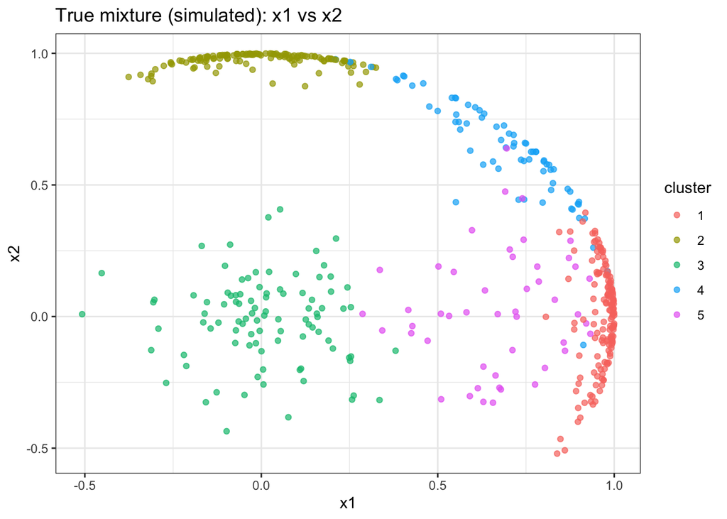

```r
plots <- plot_projections(X, label = z, title_prefix = "True mixture (simulated)")
plots$p12
```

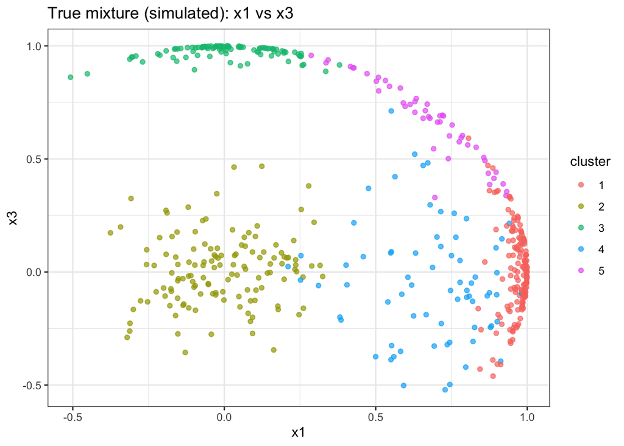

```r
plots$p13
```

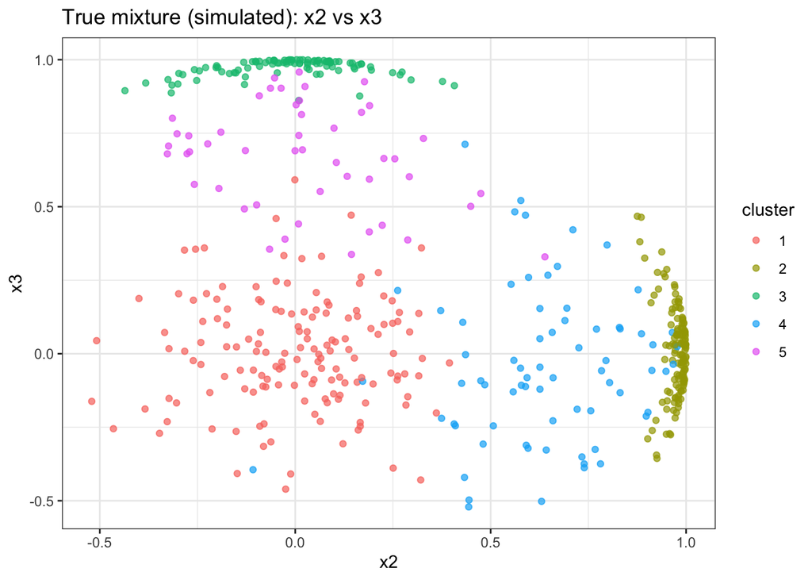

```r
plots$p23
```

```r
# Interactive 3D plot
rgl::open3d()
```

```
## glX
##   1
```

```r
cols <- as.integer(factor(z))
rgl::plot3d(X, col = cols, size = 5, type = "s")
rgl::title3d("Simulated mixture on the unit sphere")
rgl::rglwidget()
```

[interactive chart not shown]

# 6 Attempting to fix mixtures of vMF for multiple K, and select K

We will fit vMF mixtures, and compute BIC (grid over K). BIC is used for model selection, and helps us determine how well a model explains the data. This will be perfect for determining whether to use vMF or Euclidian models.

```r
K_grid <- 1:8
fits <- vector("list", length(K_grid))
names(fits) <- paste0("K", K_grid)

# Data must be in a matrix.

X_unit <- normalize_rows(X)

for (K in K_grid) {
  fits[[paste0("K", K)]] <- movMF::movMF(X_unit, k = K, nruns = 10)
}

# Extract, store BIC values
bic_df <- data.frame(
  K = K_grid,
  BIC = sapply(fits, BIC)
)

bic_df
```

```
##    K        BIC
## K1 1  -654.6306
## K2 2 -1009.1704
## K3 3 -1427.5734
## K4 4 -1461.2247
## K5 5 -1497.4027
## K6 6 -1490.6106
## K7 7 -1470.2777
## K8 8 -1454.1408
```

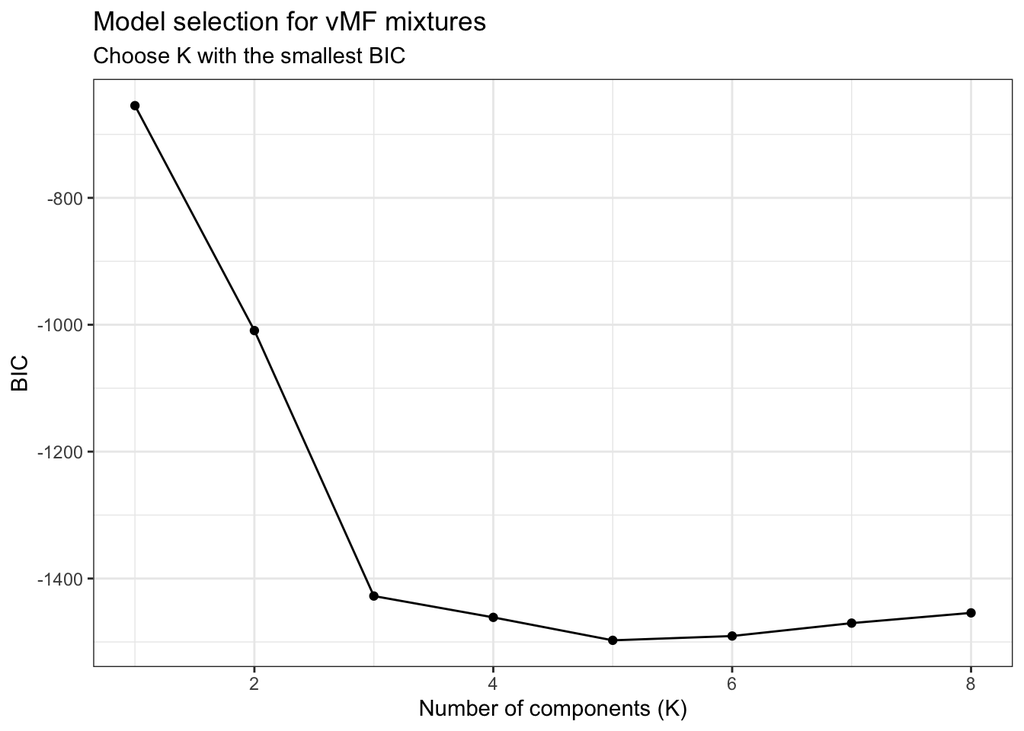

```r
ggplot(bic_df, aes(x = K, y = BIC)) +
  geom_point() +
  geom_line() +
  theme_bw() +
  labs(title = "Model selection for vMF mixtures", subtitle = "Choose K with the smallest BIC", x = "Number of components (K)", y = "BIC")
```

```r
K_hat <- bic_df$K[which.min(bic_df$BIC)]
K_hat
```

```
## [1] 5
```

```r
best_fit <- fits[[paste0("K", K_hat)]]
```

1. BIC is determining what amount of models the data most likely has, with a lower BIC being better. In this case, BIC shows that 5 is the best fit.
2. This chosen K makes sense, as we did indeed select 5 mixtures to work with earlier. However, the BIC was nearly flat, which indicate that movRF was starting to having some trouble.

# 7 Cluster Assignments, Visualization (vMF mixture)

```r
vmf_cluster <- predict(best_fit)
vmf_cluster <- factor(vmf_cluster)
table(vmf_cluster)
```

```
## vmf_cluster
##   1   2   3   4   5
##  40 137  66  99 158
```

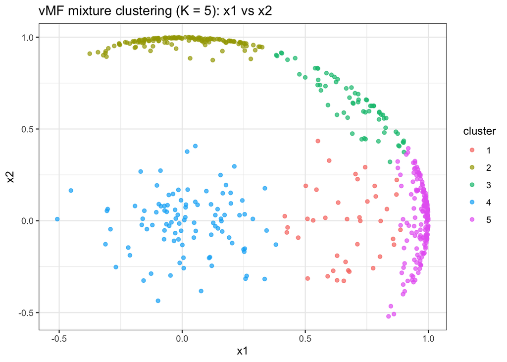

```r
plots_vmf <- plot_projections(X_unit, label = vmf_cluster, title_prefix = paste0("vMF mixture clustering (K = ", K_hat, ")"))
plots_vmf$p12
```

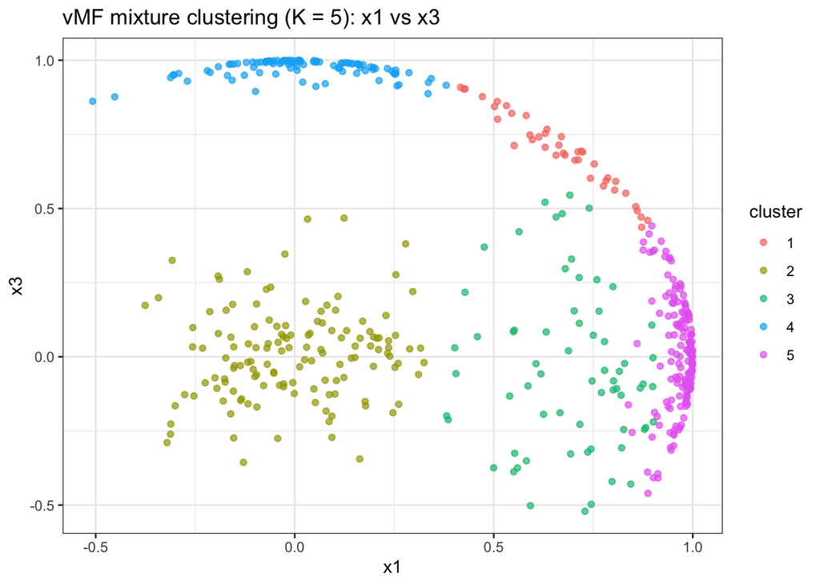

```r
plots_vmf$p13
```

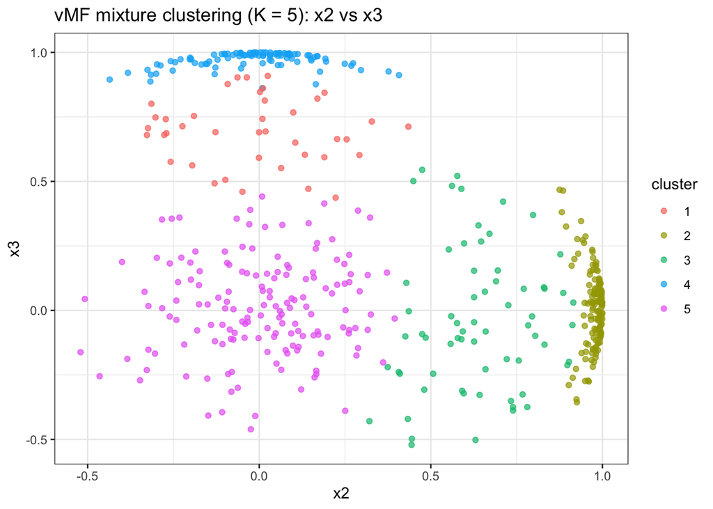

```r
plots_vmf$p23
```

```r
theta_hat <- best_fit$theta

kappa_hat <- apply(theta_hat, 2, function(x) norm(x,"2"))
kappa_hat
```

```
## [1] 31.35080 38.18411 37.19693
```

```r
mu_hat <- apply(theta_hat, 2, function(x) x/norm(x,"2"))
mu_hat
```

```
##           [,1]         [,2]         [,3]
## 1 4.545000e-01 -0.004631551  0.388024859
## 2 8.114459e-05  0.970925334  0.005399256
## 3 3.361160e-01  0.239088159 -0.013326793
## 4 2.346601e-02 -0.010007414  0.921529268
## 5 8.245636e-01  0.004387342  0.003709630
```

movMF calculated five clusters here, all somewhat reminiscent of the actual clusters we created in the simulation.

Simulated vMF cluster means: 1: Weight: 0.30, mean: (1, 0, 0), K: 25 2: Weight: 0.25, mean: (0, 1, 0), K: 40 3: Weight: 0.20, mean: (0, 0, 1), K: 30 4: Weight: 0.15, mean: (1, 1, 0), K: 15 5: Weight: 0.10, mean: (1, 0, 1), K: 20

Estimated vMF clusters means:

1: mean: (0.454, -0.005, 0.388) -> Sim 5 2: mean: (0.000, 0.971, 0.005) -> Sim 2 3: mean: (0.336, 0.239, -0.0133) -> Sim 4 4: mean: (0.023, -0.010, 0.922) -> Sim 3 5: mean: (0.824, 0.004, 0.004) -> Sim 1

It is fairly obvious still which simulated cluster each estimated cluster is mapping to. However, movMF is beginning to struggle a bit with simulated mixtures 5 and 4, who have two directions they tend towards.

# 8 Comparisons with Euclidean k-means

We will now test Euclidian k-means on the same data.

```r
set.seed(123)
km <- kmeans(X_unit, centers = K_hat, nstart = 25)
km_cluster <- factor(km$cluster)

table(km_cluster)
```

```
## km_cluster
##   1   2   3   4   5
##  60  54 102 142 142
```

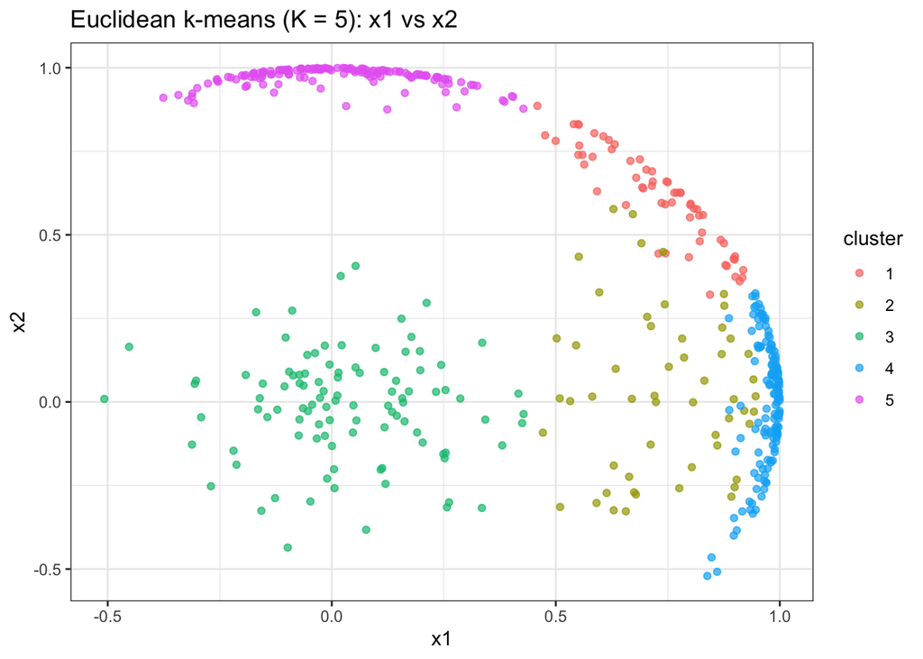

```r
plots_km <- plot_projections(X_unit, label = km_cluster, title_prefix = paste0("Euclidean k-means (K = ", K_hat, ")"))
plots_km$p12
```

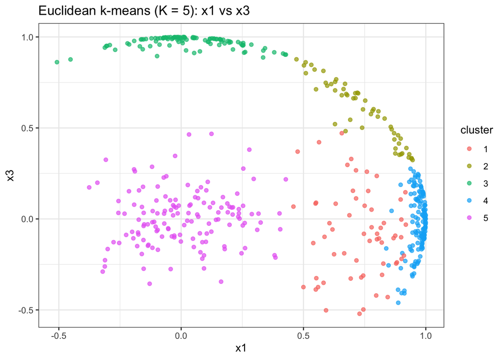

```r
plots_km$p13
```

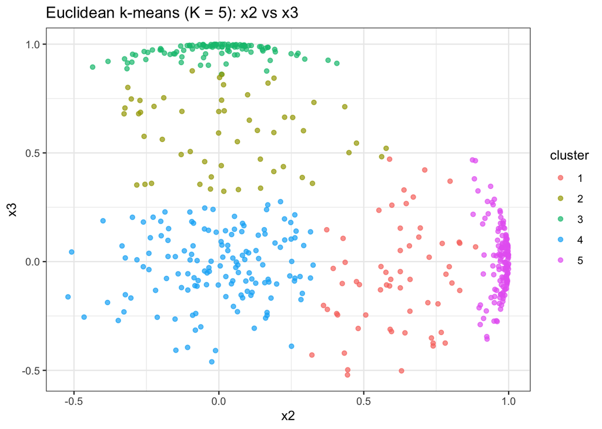

```r
plots_km$p23
```

### 8.0.1 Agreement Metric

```r
# Simple agreement table (labels might be permuted, so interpret carefully)
table(vmf_cluster, km_cluster)
```

```
##            km_cluster
## vmf_cluster   1   2   3   4   5
##           1   0  37   3   0   0
##           2   0   0   0   0 137
##           3  57   4   0   0   5
##           4   0   0  99   0   0
##           5   3  13   0 142   0
```

An interpretation of this is what cluster corresponds to each cluster from km to vmf. For example, km cluster 2 and vmf cluster 1 mostly correspond to each other.

They appear to split the data slightly differently, but are mostly in agreement. vMF 4 and km 3 are in total agreement, but there is some variance with vMF 5.

# 9 Comparative Study

In this study, we determine when spherical modeling outperforms Euclidian clustering, and vice versa. To do this, a simulation grid with varying sample sizes, concentration, and separation among cluster centers is created. vMF and k-means models are ran against the simulation grid.

```r
library(dplyr)
simulate_mixture <- function(n, K, kappas, mus, w = rep(1/K, K)) {
  z <- sample(1:K, size = n, replace = TRUE, prob = w)
  X <- matrix(NA, nrow = n, ncol = length(mus[[1]]))
  for (k in 1:K) {
    nk <- sum(z == k)
    if (nk > 0) X[z == k, ] <- movMF::rmovMF(nk, theta = mus[[k]]*kappas[k])
  }
  list(X = normalize_rows(X), z = z)
}

within_cosine <- function(X, cluster) {
  cluster <- as.integer(factor(cluster))
  K <- max(cluster)
  out <- numeric(K)
  for (k in 1:K) {
    idx <- which(cluster == k)
    if (length(idx) <= 1) { out[k] <- NA; next }
    mu_hat <- colMeans(X[idx, , drop = FALSE])
    mu_hat <- mu_hat / sqrt(sum(mu_hat^2))
    out[k] <- mean(X[idx, , drop = FALSE] %*% mu_hat)
  }
  mean(out, na.rm = TRUE)
}

grid <- expand.grid(
  n = c(100, 300, 600),
  kappa = c(5, 10, 20, 30),
  rep = 1:50
)

grid <- as_tibble(grid)
grid
```

```
## # A tibble: 600 × 3
##        n kappa   rep
##    <dbl> <dbl> <int>
##  1   100     5     1
##  2   300     5     1
##  3   600     5     1
##  4   100    10     1
##  5   300    10     1
##  6   600    10     1
##  7   100    20     1
##  8   300    20     1
##  9   600    20     1
## 10   100    30     1
## # ℹ 590 more rows
```

```r
K <- 5
mus <- list(
  c(1, 0, 0),
  c(0, 1, 0),
  c(0, 0, 1),
  c(1, 1, 0),
  c(0, 1, 1)
)
mus <- lapply(mus, function(m) m / sqrt(sum(m^2)))

results <- grid %>%
  rowwise() %>%
  mutate(
    sim = list(simulate_mixture(n = n, K = K, kappas = rep(kappa, K), mus = mus)),
    # vMF mixture clustering
    vmf_fit = list(tryCatch(
      movMF::movMF(sim$X, k = K, nruns = 10),
      error = function(e) NULL
    )),

    vmf_cluster = list(
      if (is.null(vmf_fit)) NA else predict(vmf_fit)
    ),

    vmf_score = if (all(is.na(vmf_cluster))) NA else within_cosine(sim$X, vmf_cluster),

    # Euclidean kmeans clustering
    km = list(kmeans(sim$X, centers = K, nstart = 20)),
    km_score = within_cosine(sim$X, km$cluster)
  ) %>%
  ungroup() %>%
  select(n, kappa, rep, vmf_score, km_score)

head(results)
```

```
## # A tibble: 6 × 5
##       n kappa   rep vmf_score km_score
##   <dbl> <dbl> <int>     <dbl>    <dbl>
## 1   100     5     1     0.913    0.910
## 2   300     5     1     0.883    0.899
## 3   600     5     1     0.888    0.889
## 4   100    10     1     0.936    0.934
## 5   300    10     1     0.926    0.928
## 6   600    10     1     0.929    0.926
```

```r
summary_df <- results %>%
  group_by(n, kappa) %>%
  summarise(
    vmf_mean = mean(vmf_score, na.rm = TRUE),
    km_mean  = mean(km_score, na.rm = TRUE),
    .groups = "drop"
  ) %>%
  tidyr::pivot_longer(cols = c(vmf_mean, km_mean),
                      names_to = "method", values_to = "score") %>%
  mutate(method = dplyr::recode(method, vmf_mean = "vMF mixture", km_mean = "Euclidean k-means"))

summary_df
```

```
## # A tibble: 24 × 4
##        n kappa method            score
##    <dbl> <dbl> <chr>             <dbl>
##  1   100     5 vMF mixture       0.907
##  2   100     5 Euclidean k-means 0.901
##  3   100    10 vMF mixture       0.935
##  4   100    10 Euclidean k-means 0.934
##  5   100    20 vMF mixture       0.957
##  6   100    20 Euclidean k-means 0.957
##  7   100    30 vMF mixture       0.970
##  8   100    30 Euclidean k-means 0.970
##  9   300     5 vMF mixture       0.891
## 10   300     5 Euclidean k-means 0.892
## # ℹ 14 more rows
```

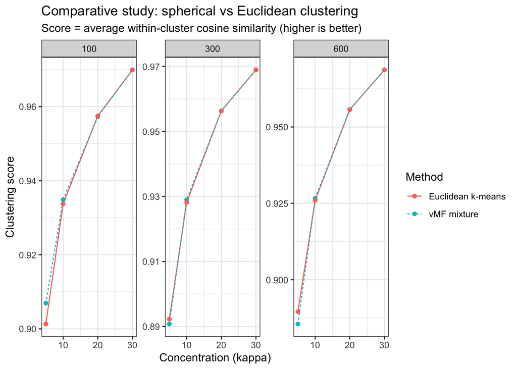

```r
ggplot(summary_df, aes(x = kappa, y = score, group = method, linetype = method, color = method)) +
  geom_line() +
  geom_point() +
  facet_wrap(~ n, scales = "free_y") +
  theme_bw() +
  labs(
    title = "Comparative study: spherical vs Euclidean clustering",
    subtitle = "Score = average within-cluster cosine similarity (higher is better)",
    x = "Concentration (kappa)",
    y = "Clustering score",
    color = "Method",
    linetype = "Method"
  )
```

Performance is nearly identical, it is very hard to tell the difference between Euclidian vs vMF analysis. A deeper look at the accuracy has to be taken, and across multiple mixture sizes. For now, however, let’s just try to see the difference between the two lines.

```r
library(tidyr)

diff_df <- summary_df %>%
  pivot_wider(names_from = method, values_from = score) %>%
  mutate(
    diff = `vMF mixture` - `Euclidean k-means`,
    winner = ifelse(diff > 0, "vMF better", "k-means better")
  )
```

[figure not shown]

```r
ggplot(diff_df, aes(x = kappa)) +

  geom_ribbon(
    aes(
      ymin = ifelse(winner == "vMF better", `Euclidean k-means`, `vMF mixture`),
      ymax = ifelse(winner == "vMF better", `vMF mixture`, `Euclidean k-means`),
      fill = winner
    ),
    alpha = 0.6
  ) +

  geom_line(aes(y = `vMF mixture`, color = "vMF mixture"), linewidth = 0) +
  geom_line(aes(y = `Euclidean k-means`, color = "Euclidean k-means"), linewidth = 0) +

  geom_point(aes(y = `vMF mixture`, color = "vMF mixture"), size = 0.8) +
  geom_point(aes(y = `Euclidean k-means`, color = "Euclidean k-means"), size = 0.8) +

  facet_wrap(~ n, scales = "free_y") +
  theme_bw() +

  scale_fill_manual(values = c(
    "vMF better" = "violet",
    "k-means better" = "red"
  )) +

  labs(
    title = "Comparative study: spherical vs Euclidean clustering",
    subtitle = "Shaded area shows which method performs better",
    x = "Concentration (kappa)",
    y = "Clustering score",
    fill = "Winner",
    color = "Method"
  )
```